# Song Project

December 14, 2020

```r
library(rvest)
library(tidyverse)
library(genius)
library(tidytext)
library(gridExtra)
data("stop_words")
data("sentiments")
```

```r
# read webpage for Grammy Awards
webpage <- read_html("https://en.wikipedia.org/wiki/Grammy_Award_for_Record_of_the_Year")

# copy xpath for table of 1980s
XPATH80 <- '/html/body/div[3]/div[3]/div[5]/div[1]/table[5]'

# run the following to create table of songs from 1980s
table_1980 <-
  webpage %>%
  html_nodes(xpath = XPATH80) %>%
  html_table(fill = TRUE)

d1980 <- table_1980[[1]]

# 1990
XPATH90 <- '/html/body/div[3]/div[3]/div[5]/div[1]/table[6]'

# run the following to create table of songs from 1990s
table_1990 <-
  webpage %>%
  html_nodes(xpath = XPATH90) %>%
  html_table(fill = TRUE)

d1990 <- table_1990[[1]]

# 2000
XPATH00 <- '/html/body/div[3]/div[3]/div[5]/div[1]/table[7]'

# run the following to create table of songs from 2000s
table_2000 <-
  webpage %>%
  html_nodes(xpath = XPATH00) %>%
  html_table(fill = TRUE)

d2000 <- table_2000[[1]]

# 2010
XPATH10 <- '/html/body/div[3]/div[3]/div[5]/div[1]/table[8]'

# run the following to create table of songs from 2010s
table_2010 <-
  webpage %>%
  html_nodes(xpath = XPATH10) %>%
  html_table(fill = TRUE)

d2010 <- table_2010[[1]]
```

```r
# my clean data all binded together
ROY <- rbind(d1980, d1990, d2000, d2010) %>%
  na.omit() %>%
  rename(year = 'Year[I]', track = 'Record', artist = 'Artist(s)') %>%
  extract(col = year, into = "year", regex = "(\\d{4})")
```

```r
# get lyrics for all songs
lyrics <- ROY %>%
  add_genius(artist, track, type = "lyrics")
```

```r
# add decade variable
lyrics <- lyrics %>%
  mutate(decade = ifelse(grepl("198", year), "1980s",
                  ifelse(grepl("199", year), "1990s",
                  ifelse(grepl("200", year), "2000s", "2010s"))))
```

```r
lyric <- lyrics %>%
  unnest_tokens(word, lyric)
```

# graph 1: BoxPlot

According to these box plots, we can see that in the 1980’s the average amount of words that were in songs from this decade ranged from about 230 words to about 510 words at eyeball view. This decade also shows a couple of outliers that have more lyrics and a lonely outlier with no lyrics at all. The average median amount of words per song in the 1990’s was somewhere around 260 words. However, during this decade we see several more outliers above the box plot indicating that there were some top grammy’s that won having around 500 to 750 words per song. This is also around the time Eminem became a very popular rapper and has also won a few grammy’s, but didn’t necessarily win any until the 2000’s. This is the decade we see that shows the number of lyrics for hit songs started having more words per song. This could have been the decade that really started the rapping business.

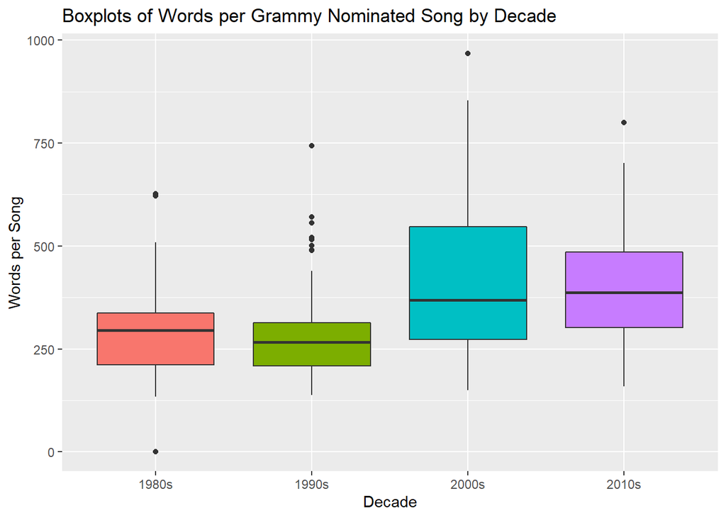

```r
lyric %>%
  group_by(track, decade) %>%
  summarise(count = sum(n())) %>%
  ggplot(aes(x = decade, y = count, fill = decade)) +
  geom_boxplot() +
  theme(legend.position = "None") +
  xlab("Decade") +
  ylab("Words per Song") +
  ggtitle("Boxplots of Words per Grammy Nominated Song by Decade")
```

# Column Graph

```r
# variable of the words we didn't want
Rubric_stop <- data.frame(word = c("ba", "du", "yeah", "da", "ya", "ooh", "gonna", "na", "uh", "la", "hol"))
```

```r
graph2 <- lyrics %>%
  unnest_tokens(word, lyric)
```

```r
# the anti-join function is supposed to do the opposite what what a join function would do. That is, it is supposed to return the data rows from the left without matching anything on the right.
graph2 <- graph2 %>%
  anti_join(stop_words) %>%
  anti_join(Rubric_stop)
```

```r
topten <- graph2 %>%
  count(word, sort = TRUE) %>%
  filter(n >= 3) %>%
  top_n(10)
```

# graph 2: Column graph

This graph is supposed to show us how many times the top 10 most popular words in a song were used between the year 1980 to 2019. We can clearly see that “love” was the most used word between the last 4 decades. We can also see some not so meaningful words like “wanna” were pretty popular as well. it seems as though love songs have become very popular.

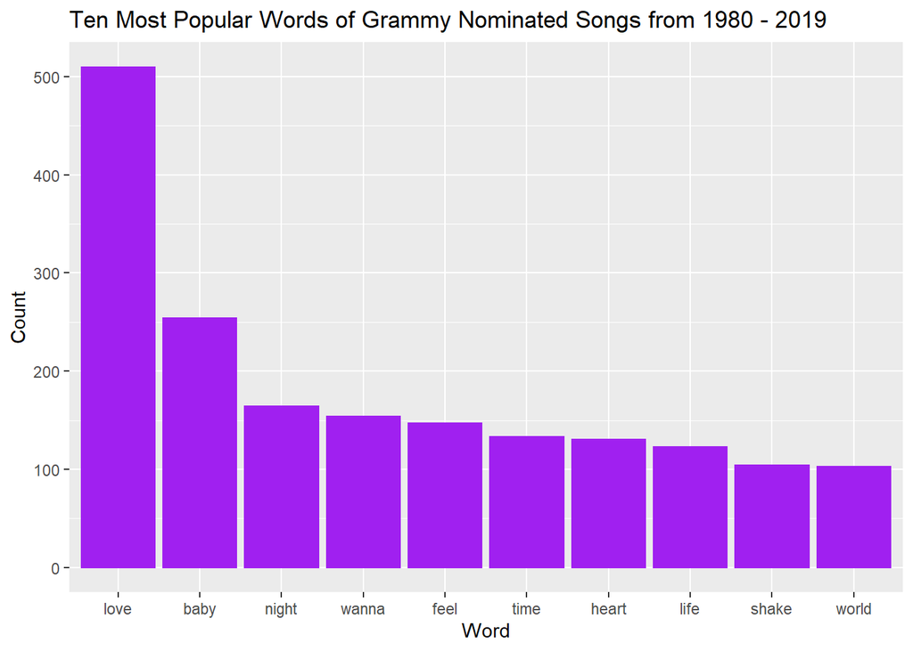

```r
# I used the reorder function to put the ten most popular words in order from the most used to the least used of the top ten.
topten %>%
  ggplot(aes(x = reorder(word, -n), y = n)) +
  geom_col(color = 'purple', fill = 'purple') +
  xlab("Word") +
  ylab("Count") +
  ggtitle("Ten Most Popular Words of Grammy Nominated Songs from 1980 - 2019")
```

```r
graph3 <- lyrics %>%
  unnest_tokens(word, lyric)
```

```r
graph3 <- graph3 %>%
  anti_join(stop_words) %>%
  anti_join(Rubric_stop)
```

```r
first <- graph3 %>%
  group_by(year, decade) %>%
  count(word, sort = TRUE) %>%
  filter(n >= 30) %>%
  top_n(10)
```

```r
first <- first %>%
  filter(decade == "1980s") %>%
  ggplot(aes(x = reorder(word, -n), y = n)) +
  geom_col(color = 'blue', fill = 'blue') +
  xlab("Word") +
  ylab("Count") +
  ggtitle("1980s")
```

```r
second <- graph3 %>%
  group_by(year, decade) %>%
  count(word, sort = TRUE) %>%
  filter(n >= 17) %>%
  top_n(10)
```

```r
second <- second %>%
  filter(decade == "1990s") %>%
  ggplot(aes(x = reorder(word, -n), y = n)) +
  geom_col(color = 'green', fill = 'green') +
  xlab("Word") +
  ylab("Count") +
  ggtitle("1990s")
```

```r
third <- graph3 %>%
  group_by(year, decade) %>%
  count(word, sort = TRUE) %>%
  filter(n >= 25) %>%
  top_n(10)
```

```r
third <- third %>%
  filter(decade == "2000s") %>%
  ggplot(aes(x = reorder(word, -n), y = n)) +
  geom_col(color = 'orange', fill = 'orange') +
  xlab("Word") +
  ylab("Count") +
  ggtitle("2000s")
```

```r
forth <- graph3 %>%
  group_by(year, decade) %>%
  count(word, sort = TRUE) %>%
  filter(n >= 30) %>%
  top_n(10)
```

```r
forth <- forth %>%
  filter(decade == "2010s") %>%
  ggplot(aes(x = reorder(word, -n), y = n)) +
  geom_col(color = 'purple', fill = 'purple') +
  xlab("Word") +
  ylab("Count") +
  ggtitle("2010s")
```

# graph 3: 4x column graphs by decade

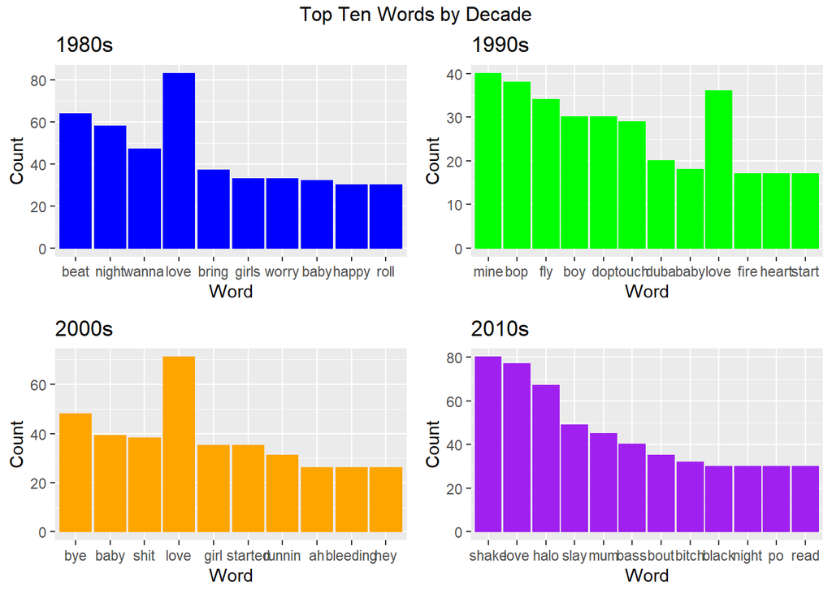

```r
# this function separates our 4 graphs separately.
grid.arrange(first, second, third, forth, nrow =2, ncol = 2, top = "Top Ten Words by Decade")
```

```r
# new variable for sentiment
sentiments <- sentiments%>%
  mutate(score = ifelse(grepl("negative", sentiment), "0", "1"))
```

```r
graph4 <- lyrics %>%
  unnest_tokens(word, lyric)
```

```r
graph4 <- graph4 %>%
  anti_join(stop_words) %>%
  anti_join(Rubric_stop) %>%
  inner_join(sentiments, by = "word") %>%
  group_by(year, decade, sentiment, score)
```

# graph 4: bar graph

This graph shows the net sentiment score by year. Based on the Grammy award winning songs that were released as the most popular, it looks as though the 2010’s had one pretty negative year and one very positive year. Where the other 3 decades show roughly about the same level of overall sentiment scores.

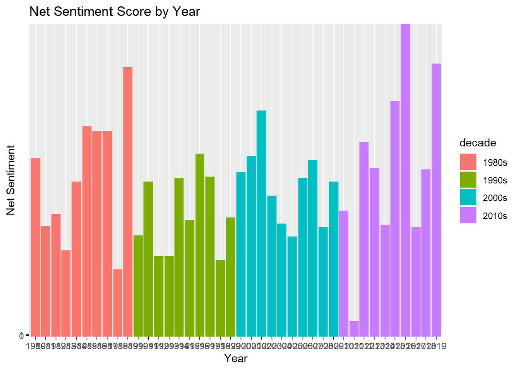

```r
graph4 %>%
  ggplot(aes(x = year, y = score)) +
  aes(fill= decade) +
  geom_bar(stat = "identity") +
  xlab("Year") +
  ylab("Net Sentiment") +
  ggtitle("Net Sentiment Score by Year")
```

```r
graph5 <- lyrics %>%
  unnest_tokens(word, lyric)
```

```r
graph5 <- graph5 %>%
  anti_join(stop_words) %>%
  anti_join(Rubric_stop) %>%
  inner_join(sentiments, by = "word") %>%
  group_by(decade, sentiment, score)
```

# graph 5: bar graph

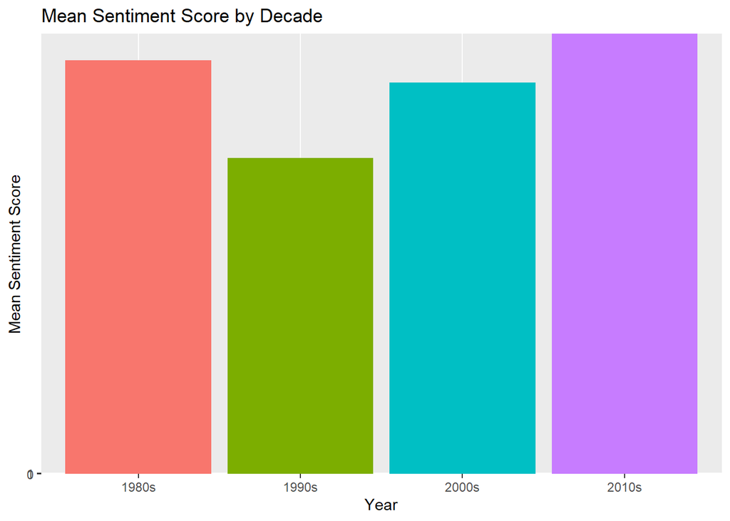

```r
graph5 %>%
  ggplot(aes(x = decade, y = score)) +
  aes(fill = decade) +
  geom_bar(stat = "identity") +
  theme(legend.position = "None") +
  xlab("Year") +
  ylab("Mean Sentiment Score") +
  ggtitle("Mean Sentiment Score by Decade")
```

```r
graph6 <- lyrics %>%
  unnest_tokens(word, lyric)
```

```r
graph6 <- graph6 %>%
  anti_join(stop_words) %>%
  anti_join(Rubric_stop) %>%
  inner_join(sentiments, by = "word") %>%
  group_by(decade, sentiment, score)
```

# graph 6: attempt of a point graph

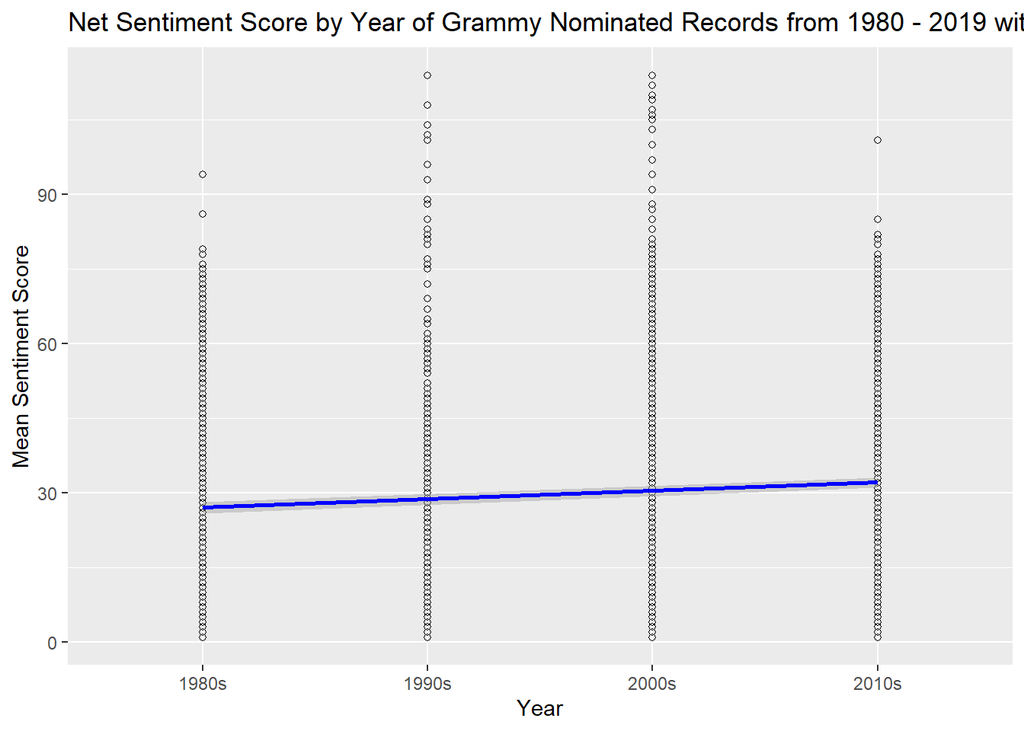

```r
graph6 %>%
  ggplot(aes(x = decade, y = line)) +
  geom_point(shape = 1) +
  geom_smooth(method = lm, na.rm = TRUE, fullrange = TRUE, aes(group = 1), color = "blue") +
  xlab("Year") +
  ylab("Mean Sentiment Score") +
  ggtitle("Net Sentiment Score by Year of Grammy Nominated Records from 1980 - 2019 with Linear Model Fit")
```